# Project 4 Description Unsupervised Learning

Jyotishka Datta

April 12, 2020

# Unsupervised Learning

Unsupervised learning refers to learning problems where we have unlabelled data (e.g. variables $X$) without any response variable $y$ that can be used in a supervised set-up. Usually, unsupervised learning algorithm refers to the task of learning the latent structure e.g. group membership, from the data. This project considers different methods for one specific task under unsupervised learning - clustering.

This document will show demonstration of two popular methods: $K$-means and Bayesian finite mixture model. Your goal would be to apply these methods for either a simulated data where the true cluster labels are known to you, but not to the algorithm and you’ll test methods on their ability to learn the correct cluster memberships. If you do this, generate a data with many variables and assign labels based on some of the predictors and then try to cluster the points.

Alternatively, you can also use a real data set from NCI60 (Cell lines for different cancer types) given in the real data section.

The k-means examples are taken from the ISLR book website and the finite mixture model examples are taken from Matthew Stephens’ website.

# Approach 1: K-means clustering

This simulated data has two true clusters, the first 25 belongs to a different class than the last 25.

```r
set.seed(2)
x=matrix(rnorm(50*2), ncol=2)
x[1:25,1]=x[1:25,1]+3
x[1:25,2]=x[1:25,2]-4
```

First we perform $K$-means clustering with $k = 2$.

```r
km.out=kmeans(x,2,nstart=20)
km.out$cluster
```

```
 [1] 1 1 1 1 1 1 1 1 1 1 1 1 1 1 1 1 1 1 1 1 1 1 1 1 1 2 2 2 2 2 2 2 2 2 2 2 2 2
[39] 2 2 2 2 2 2 2 2 2 2 2 2
```

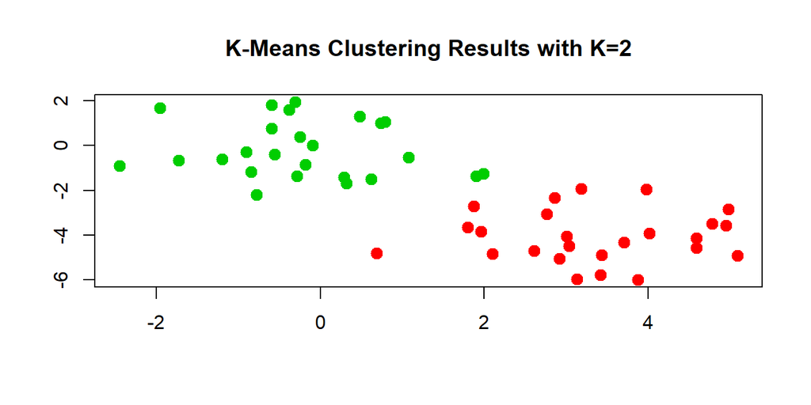

```r
plot(x, col=(km.out$cluster+1), main="K-Means Clustering Results with K=2", xlab="", ylab="", pch=20, cex=2)
```

The k-means clustering algorithm perfectly clusters the data in this case.

## Choosing $K$

However, in reality, we won’t know if there are really two clusters, and we can do k-means with $K = 3$.

```r
set.seed(4)
km.out=kmeans(x,3,nstart=20)
km.out
```

```
K-means clustering with 3 clusters of sizes 17, 23, 10

Cluster means:
        [,1]        [,2]
1  3.7789567 -4.56200798
2 -0.3820397 -0.08740753
3  2.3001545 -2.69622023

Clustering vector:
 [1] 1 3 1 3 1 1 1 3 1 3 1 3 1 3 1 3 1 1 1 1 1 3 1 1 1 2 2 2 2 2 2 2 2 2 2 2 2 2
[39] 2 2 2 2 2 3 2 3 2 2 2 2

Within cluster sum of squares by cluster:
[1] 25.74089 52.67700 19.56137
 (between_SS / total_SS =  79.3 %)

Available components:

[1] "cluster"      "centers"      "totss"        "withinss"     "tot.withinss"
[6] "betweenss"    "size"         "iter"         "ifault"
```

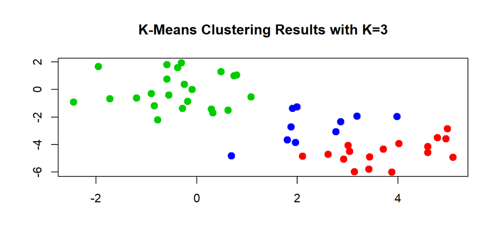

```r
plot(x, col=(km.out$cluster+1), main="K-Means Clustering Results with K=3", xlab="", ylab="", pch=20, cex=2)
```

This will split up one of the clusters into two spurious clusters.

In general, choosing the number $K$ is a hard question to answer, and there’s no consensus. Here is a paper that looks into this question:

1. Estimating the number of clusters using cross-validation Wei Fu and Patrick O. Perry (https://arxiv.org/pdf/1702.02658.pdf)[https://arxiv.org/pdf/1702.02658.pdf]

## Multiple starts

We can calculate the value of total within sum of squares that we wish to minimise. If we let $C_1, C_2, \ldots, C_K$ be the sets containing the indices for the $K$ clusters, and $W(C_K)$ be the amount by which observations within the same cluster differ from each other, then the total within cluster variation would be:

$$\text{minimize}_{C_1, \ldots, C_K} \{ \sum_{k=1}^{K} W(C_k) \}$$

To run the kmeans() function in R with multiple initial cluster assignments, we use the nstart argument. Note that `km.out$tot.withinss` is the total within-cluster sum of squares, which we seek to minimize by performing K-means clustering.

```r
set.seed(3)
km.out=kmeans(x,2,nstart=20)
km.out$tot.withinss
```

```
[1] 128.6066
```

```r
km.out=kmeans(x,3,nstart=20)
km.out$tot.withinss
```

```
[1] 97.97927
```

```r
km.out=kmeans(x,10,nstart=20)
km.out$tot.withinss
```

```
[1] 21.99457
```

# Approach 2: Finite mixture model

As we have discussed before, in many situations the posterior is intractable, i.e. without any `nice’ analytic closed form expression and the Markov Chain Monte Carlo ideas are very useful in those cases.

The first example we will see involves a finite mixture of Gaussians.
$$X_1, X_2, \ldots, X_n \stackrel{IID}{\sim} f(\cdot).$$
where,
$$f(\cdot) = \sum_{k=1}^{K} \pi_k ~N(\cdot ; \mu_k, 1)$$

## Parameters

Here $\pi_1, \pi_2, \ldots, \pi_K$ are probabilities that an observation will belong the $K$ clusters.

Obviously, $\pi_i \ge 0$ and $\sum_{i=1}^{K} \pi_i = 1$.

The parameters $\mu_k$, $k = 1, \ldots, K$ are the centers for each of the $K$ groups and they are also our parameter of interest.

### Example 1

These models are typically used in modeling multimodal data distributions, where the multiple modes might be due to some underlying grouping mechanism.

Here is a simple example, suppose there are two groups of individuals, about half of them with higher blood pressure and the other half of with very low b.p.. One way of modeling this would be as follows:

```r
n <- 5000
bp <- numeric(n)
z <- numeric(n)
for(i in 1:n) {
  z.i <- rbinom(1,1,0.5)
  if(z.i == 0) bp[i] <- rnorm(1, mean = 100, sd = 5)
  else bp[i] <- rnorm(1, mean = 140, sd = 5)
  z[i] = z.i
}
```

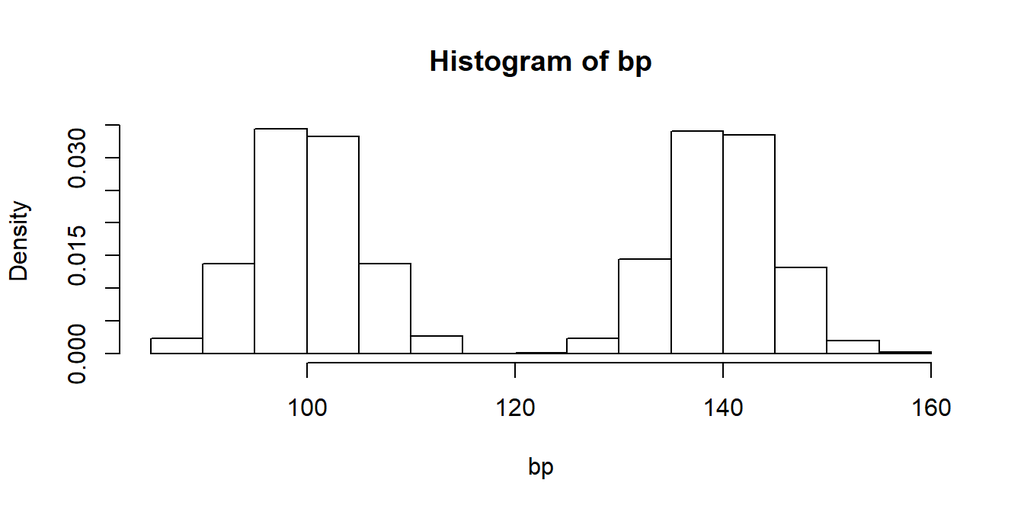

```r
hist(bp, freq = F)
```

This is a clear bimodal distribution. The individual components are still normal.

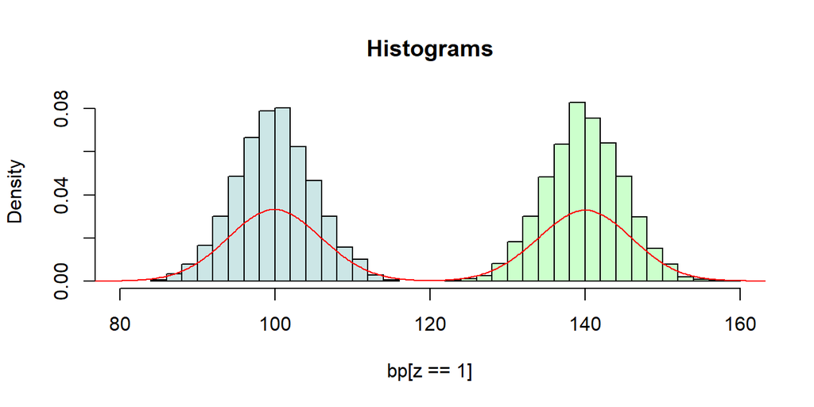

### Example 2

Now suppose we look at the height distribution for a class of students, and suppose that the height of a randomly choses male is normally distributed 5’9" with s.d. 2.5 inches and the height of a randomly chosen female is $N(5'4", 2.5)$. However, the composition is 75-25.

```r
n <- 5000
heights <- numeric(n)
z <- numeric(n)
for(i in 1:n) {
  z.i <- rbinom(1,1,0.75)
  if(z.i == 0) heights[i] <- rnorm(1, mean = 69, sd = 2.5)
  else heights[i] <- rnorm(1, mean = 64, sd = 2.5)
  z[i] = z.i
}
```

Now we see that histogram is unimodal. Are heights normally distributed under this model? We plot the corresponding densities below:

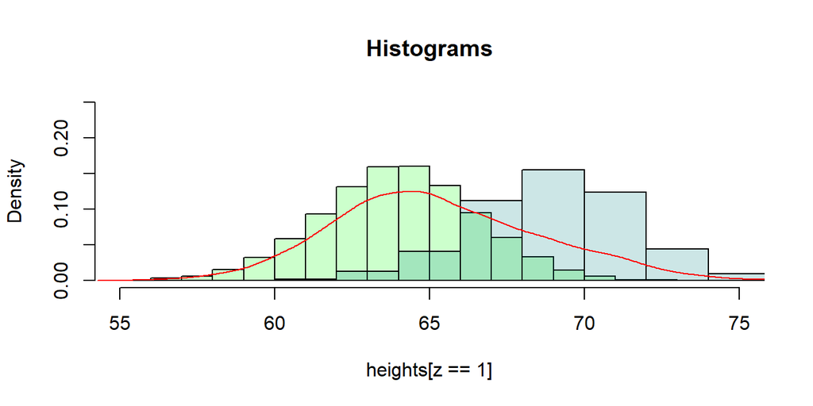

Here the individual components are normal but the population distribution is not (because it’s not even symmetric).

### Mixture model

- Both these examples show draws from a mixture model that assumes each observation $X_i$ is drawn from one of the $K$ components.
- Each $X_i$ is associated with a categorical variable $Z_i$ that indicates which component the obsrvation comes from. $Z_i$ can be called cluster or group indicator or if you thinnk of the groups as communities, then $Z_i$ is a community membership or labels.
- Often times, we are given the data without the labels, e.g. all the blood pressure values without the high/low label or all height data without the gender information.
- The goal is to develop an inference procedure that can learn these labels as well as the different means given the unlabelled data.

First, by the law of total probability the marginal probability of $X$ is:

$$P(X_i = x) = \sum_{k=1}^{K}P(X_i = x \mid Z_i = k) P(Z_i = k) \\
= \sum_{k=1}^{K} P(X_i = x \mid Z_i = k) \pi_k$$

$\pi_i$: mixture weights. $P(X_i = x \mid Z_i = k)$: mixture components.

The mixture components can be either discrete or continuous, and correspondingly we should have probability mass functions or probability density functions.

**Normal mixtures**

In our examples, the groups had Normally distributed mixture components, so the marginal components are $\phi(x; \mu_k, \sigma_k)$ where $\phi(\cdot)$ is the Normal density function.

$$P(X_i = x) = \sum_{k=1}^{K} \phi(x; \mu_k, \sigma_k) ~ \pi_k \\
= \sum_{k=1}^{K} \frac{1}{\sqrt{2 \pi}\sigma_k} e^{-\frac{(x-\mu_k)^2}{2\sigma_k^2}}~ \pi_k$$

**Likelihood** If we observe samples $X_1, X_2, \ldots, X_n$ independently from this mixture, the complete likelihood for $\pi$ is:

$$\begin{align}
L(\pi) & = \prod_{i=1}^{n} P(X_i \mid \pi) \\
& = \prod_{i=1}^{n} \sum_{k=1}^{K} P(X_i \mid Z_i = k) \pi_k \\
& = \prod_{i=1}^n \sum_{k=1}^{K} \phi(x_i; \mu_k, \sigma_k) ~ \pi_k
\end{align}$$

**Our goal is to estimate $\{\mu_k, \sigma_k, \pi_k, k = 1, \ldots, K\}$ given the observations $X_1, \ldots, X_n$.**

## Two strategies

- There are two popular ways of estimating the parameters:
1. Expectation-Maximization algorithm (EM)
2. Posterior inference (Gibbs)
- Both these approaches use the idea that we can introduce hidden/latent variables $Z_i$’s indicating the group membership, even when we don’t know the $Z_i$’s.
- We will now look at the Gibbs sampler but just give the intuition behind EM.

**Intuition**

- If we knew the indicators $Z_i$’s then we can easily estimate $\mu_k$ and $\sigma_k$’s.
- We can simply gather the observations $X_i$ for which $Z_i = k$, and use those observations to estimate $\mu_k$ and $\sigma_k$.
- On the other hand, $\pi_k$’s can be estimated from the proportion of points assigned to cluster $k$.
- **The EM tries to solve this by running a recursive procedure**

  Update the posterior probabilities $P(Z_i = k \mid X)$ given parameter values, and then update the parameter given these posterior probabilities later.

EM works because you can prove mathematically that the value of the log-likelihood will increase at each step.

Now, let’s go back to the other idea: Bayesian inference for mixture models. ## Gibbs sampling

We want to learn $\mu, \pi$ via $p(\mu, \pi \mid x)$. We can use a Gibbs sampler but we have to `augment’ the space to sample from $p(\mu, \pi, z \mid x)$, where $z$ is the latent group indicator.

Idea:

- Sample $\mu$ from $p(\mu \mid x, z, \pi)$
- Sample $\pi$ from $p(\pi \mid x, z, \mu)$
- Sample $z$ from $p(z \mid x, \mu, \pi)$
- Here all these are easy to sample from.
- **Go to whiteboard**

### Gaussian is conjugate to Gaussian mean

$$X_1, X_2, \ldots, X_n \stackrel{IID}{\sim} N(\mu, \sigma^2) \\
\mu \sim N(0, \tau^2)$$

It follows that the posterior on $\mu$ would be another Gaussian:
$$\mu \mid X_1, \ldots, X_n \sim N(\hat{\mu}, \hat{\sigma}^2) \\
\text{where } \hat{\mu} = \frac{n/\sigma^2}{n/\sigma^2+1/\tau^2} \bar{x}, \; \hat{\sigma}^2 = \frac{1}{n/\sigma^2+1/\tau^2}$$

Clearly, as $n \to \infty$, $\hat{\mu} \to \bar{x}$, i.e. **the effect of the prior washes away by the data**.

### Dirichlet is conjugate to Multinomial

This is the multivariate analog of the Beta-Binomial conjugacy property.

Recall:
$$\text{Binomial Likelihood: } f(y \mid \pi) \propto \pi^{y} (1-\pi)^{(n-y)} \\
\text{Beta Prior: } p(\pi) \propto \pi^{\alpha-1} (1-\pi)^{\beta-1}$$
Posterior would be another Beta:

$$\pi(\pi | y) \propto \pi^{y+\alpha-1} (1-\pi)^{n-y+\beta-1} \equiv \text{Beta}(y+\alpha, n-y+\beta)$$

**Note** Beta prior with both parameters equal to 1 is a Uniform prior.

$$\text{Multinomial: } p(y_1, \ldots, y_k) \propto \pi_1^{y_1}\pi_2^{y_2}\cdots (1-\sum_{i=1}^{K-1}\pi_i)^{n-\sum_{i=1}^{K-1}y_i}$$

Dirichlet prior:

$$\pi(\pi_1, \pi_2, \ldots, \pi_K) \propto \pi_1^{\alpha_1 - 1} \pi_2 ^{\alpha_2 - 1} \cdots (1-\sum_{i=1}^{K-1}\pi_i)^{\alpha_K - 1}$$
Clearly, the posterior will be another Dirichlet with parameters: $\alpha_i' = y_i + \alpha_i$.

We assume that the cluster membership indicators are categorical variables, i.e.
$$P(Z_i = j) = \pi_j \; \forall j = 1, \ldots, K$$

This is basically a Multinomial with $n = 1$. Dirichlet is still conugate to this likelihood. We will assume that the prior on $(\pi_1, \ldots, \pi_K)$ is a Dirichlet with all $\alpha_i = 1$. (In some sense this is an extension of U(0,1) to $K$ dimensions)

### Full conditional distributions

The standard Gibbs sampler should be:

- For each $i \in \{1, 2, \ldots, n\}$. Sample $z_i \mid {\mu, z_{-i}, x}$.
- For each $k \in \{ 1, 2, \ldots, K\}$ Sample $\mu_k \mid {\mu_{-k}, z, x}$.
- For each $k \in \{ 1, 2, \ldots, K\}$ Sample $\pi_k \mid {\pi_{-k}, z, x}$.

However, the conditional independence structure in mixture model allows us to simply this a great deal.

The first conditional independence relation is:
$$p(z_i \mid {\mu, z_{-i}, x}) = p(z_i \mid {\mu, x_i})$$

- Given $x, \mu$, $z_i$ does not depend on the other $z_j$’s or other $x_j$’s where $j \neq i$.
- This implies:
  $$\begin{align}
  p(z_i \mid \mu, x_i) & \propto p(z_i) \times p(x_i \mid \mu_{z_i}) \\
  & \propto \pi_k ~ p(x_i \mid \mu_k) \; \text{if} \; z_i = k, \; \forall k = 1, \ldots, K \\
  & \propto \pi_k ~ N(x_i; \; \mu_k, 1) \quad \forall k = 1, \ldots, K
  \end{align}$$
  This is a categorical distribution where the probability of the $z_i = k$ is proportional to the likelihood of the $i^{th}$ data point under the $k^{th}$ cluster.

$$p(\mu_k \mid {\mu_{-k}, z, x}) = p(\mu_k \mid z, x)$$

Given the data and the cluster indicators, the $k^{th}$ mean does not depend on the other mean parameters. We can calculate the distribution intuitively. If we know the cluster assignments, what is the conditional distribution of $\mu_k$? It is simple a posterior Gaussian, conditional on the data that were assigned to the $k^{th}$ cluster.

$$\mu_k \mid z, x \sim N(\hat{\mu_k}, \hat{\sigma}^2_k) \\
\text{where } \hat{\mu_k} = \frac{n_k/\sigma^2}{n_k/\sigma^2+1/\tau^2} \bar{x}_k, \\
1/\hat{\sigma}^2_k = n_k/\sigma^2+1/\tau^2 \\
n_k = \sum_{i=1}^{n}1\{Z_i = k\} = \text{Size of the k-th cluster}$$

### Putting it all together

$$\begin{align}
z_i \mid \mu, x_i & \sim \text{Cat}(\hat{\pi}_1, \ldots, \hat{\pi}_K) \\
\text{where } & \hat{\pi}_k \propto \pi_k ~ N(x_i; \; \mu_k, 1) \quad \forall k = 1, 2, \ldots, K\\
\mu_k \mid z, x & \sim N(\hat{\mu_k}, 1) \; \forall k = 1, 2, \ldots, K\\
\pi_k \mid {z, x} & \sim \text{Dir}(1 + n_1, 1+n_2, \ldots, 1 + n_K)
\end{align}$$

We have all the full conditionals - we can write the Gibbs sampler !

Sampling from $p(z_i \mid \mu, x_i)$: Categorical distribution.

```r
normalize = function(x){return(x/sum(x))}

#' @param x an n vector of data
#' @param pi a k vector
#' @param mu a k vector
#' @return z samples from the posterior
sample_z = function(x,pi,mu){
    dmat = outer(mu,x,"-") # k by n matrix, d_kj =(mu_k - x_j)
    p.z.given.x = as.vector(pi) * dnorm(dmat,0,1)
    p.z.given.x = apply(p.z.given.x,2,normalize) # normalize columns
    z = rep(0, length(x))
    for(i in 1:length(z)){
      z[i] = sample(1:length(pi), size=1,prob=p.z.given.x[,i],
                    replace=TRUE)
    }
    return(z)
  }
```

```r
 #' @param z an n vector of cluster allocations (1...k)
  #' @param k the number of clusters
  sample_pi = function(z,k){
    counts = colSums(outer(z,1:k,FUN="=="))
    pi = gtools::rdirichlet(1,counts+1)
    return(pi)
  }
```

Sample $\mu \mid x, z$ from Normal.

```r
#' @param x an n vector of data
  #' @param z an n vector of cluster allocations
  #' @param k the number o clusters
  #' @param prior.mean the prior mean for mu
  #' @param prior.prec the prior precision for mu
  sample_mu = function(x, z, k, prior){
    df = data.frame(x=x,z=z)
    mu = rep(0,k)
    for(i in 1:k){
      sample.size = sum(z==i)
      sample.mean = ifelse(sample.size==0,0,mean(x[z==i]))

      post.prec = sample.size+prior$prec
      post.mean = (prior$mean * prior$prec + sample.mean * sample.size)/post.prec
      mu[i] = rnorm(1,post.mean,sqrt(1/post.prec))
    }
    return(mu)
  }
```

### Full Gibbs sampler

```r
gibbs = function(x,k,niter =1000,muprior = list(mean=0,prec=0.1)){
    pi = rep(1/k,k) # initialize
    mu = rnorm(k,0,10)
    z = sample_z(x,pi,mu)
    res = list(mu=matrix(nrow=niter, ncol=k), pi = matrix(nrow=niter,ncol=k), z = matrix(nrow=niter, ncol=length(x)))
    res$mu[1,]=mu
    res$pi[1,]=pi
    res$z[1,]=z
    for(i in 2:niter){
        pi = sample_pi(z,k)
        mu = sample_mu(x,z,k,muprior)
        z = sample_z(x,pi,mu)
        res$mu[i,] = mu
        res$pi[i,] = pi
        res$z[i,] = z
    }
    return(res)
  }
```

Simulate data from model:

```r
set.seed(33)

# generate from mixture of normals
#' @param n number of samples
#' @param pi mixture proportions
#' @param mu mixture means
#' @param s mixture standard deviations
rmix = function(n,pi,mu,s){
  z = sample(1:length(pi),prob=pi,size=n,replace=TRUE)
  x = rnorm(n,mu[z],s[z])
  return(x)
}
```

Data distribution: Let the two mean parameters be $\mu_1 = -2$ and $\mu_2 = 2$ and $\sigma_1 = \sigma_2 = 1$ (known).

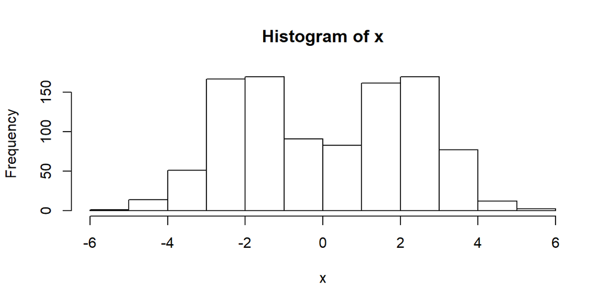

```r
x = rmix(n=1000,pi=c(0.5,0.5),mu=c(-2,2),s=c(1,1))
hist(x)
```

Run the Gibbs sampler

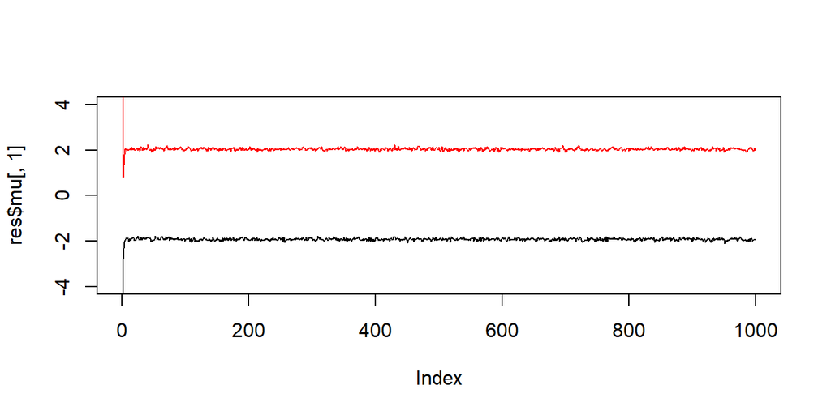

```r
res = gibbs(x,2)
  plot(res$mu[,1],ylim=c(-4,4),type="l")
  lines(res$mu[,2],col=2)
```

Fewer observations

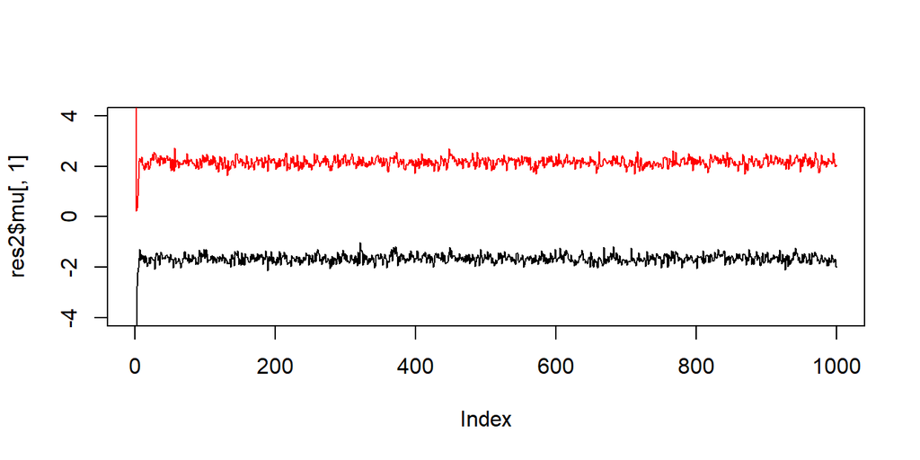

```r
x = rmix(100,c(0.5,0.5),c(-2,2),c(1,1))
  res2 = gibbs(x,2)
  plot(res2$mu[,1],ylim=c(-4,4),type="l")
  lines(res2$mu[,2],col=2)
```

Fewer still

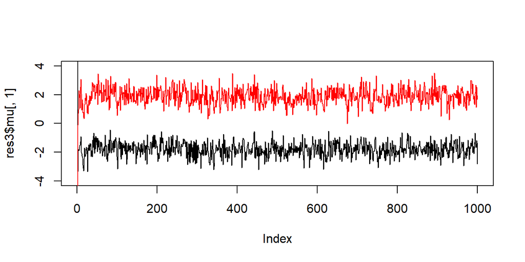

```r
x = rmix(10,c(0.5,0.5),c(-2,2),c(1,1))
  res3 = gibbs(x,2)
  plot(res3$mu[,1],ylim=c(-4,4),type="l")
  lines(res3$mu[,2],col=2)
```

Quantiles

The true values were $\mu_1 = -2$ and $\mu_2 = 2$.

```r
quantile(res$mu[-(1:10),1],c(0.05,0.95))
```

```
       5%       95%
-2.002543 -1.834683
```

```r
quantile(res$mu[-(1:10),2],c(0.05,0.95))
```

```
      5%      95%
1.962179 2.123118
```

# Real data

Here we look at the NCI60 cell lines data and the goal is to see whethere the observations cluster into the different types of cancers. However, when clustering we’ll not use the labels in the process anyhow.

Before any analysis, people often standardize the variables to have mean zero and standard deviation one. This step is optional and should be performed only if we want each gene to be on the same scale.

```r
library(ISLR)
nci.labs=NCI60$labs  ## NCI data
nci.data=NCI60$data ## Labels
dim(nci.data)
```

```
[1]   64 6830
```

```r
nci.labs[1:4]
```

```
[1] "CNS"   "CNS"   "CNS"   "RENAL"
```

```r
table(nci.labs)
```

```
nci.labs
     BREAST         CNS       COLON K562A-repro K562B-repro    LEUKEMIA
          7           5           7           1           1           6
MCF7A-repro MCF7D-repro    MELANOMA       NSCLC     OVARIAN    PROSTATE
          1           1           8           9           6           2
      RENAL     UNKNOWN
          9           1
```

```r
sd.data=scale(nci.data) ## standardize
```